# Hierarchical Cluster Analysis of USA states based on their Revenue and Expenditure, combined and separate, of 2013 data

```r
library(dplyr)
library(ggplot2)
```

#### Data Source:

```r
Finances2013=read.csv("SGF_2013_SGF003_with_ann.csv",
                       header=TRUE,stringsAsFactors=FALSE)
Finances2013=Finances2013 %>% select(GEO.display.label,SGF004,SGF005
                                     ,SGF007,SGF008,SGF009,SGF010,
                                     SGF011,SGF012,SGF013,SGF014,SGF036,SGF037,SGF038,SGF039,
                                     SGF040,SGF041,SGF042,SGF043,SGF044,SGF045,SGF046)
colnamess=paste0(Finances2013[1,],sep=",")
colnames(Finances2013)=colnamess
names(Finances2013)[names(Finances2013)=="Geographic area name,"] = "state"
```

### Hierarchical Cluster Analysis of states based on their Expenditure and Revenue

```r
colnames(Finances2013)
```

1. "state"

2. "Total Revenue - General Revenue - Intergovernmental Revenue - From Federal,"

3. "Total Revenue - General Revenue - Intergovernmental Revenue - From Local,"

4. "Total Revenue - General Revenue - Total Taxes - General Sales and Gross Receipts Taxes,"

5. "Total Revenue - General Revenue - Total Taxes - Selective Sales and Gross Receipts Taxes,"

6. "Total Revenue - General Revenue - Total Taxes - License Taxes,"

7. "Total Revenue - General Revenue - Total Taxes - Individual Income Taxes,"

8. "Total Revenue - General Revenue - Total Taxes - Corporation Net Income Taxes,"

9. "Total Revenue - General Revenue - Total Taxes - All Other Taxes,"

10. "Total Revenue - General Revenue - Current Charges,"

11. "Total Revenue - General Revenue - Miscellaneous General Revenue,"

12. "General Expenditure, by Function: - Education,"

13. "General Expenditure, by Function: - Public Welfare,"

14. "General Expenditure, by Function: - Hospitals,"

15. "General Expenditure, by Function: - Health,"

16. "General Expenditure, by Function: - Highways,"

17. "General Expenditure, by Function: - Police Protection,"

18. "General Expenditure, by Function: - Correction,"

19. "General Expenditure, by Function: - Natural Resources,"

20. "General Expenditure, by Function: - Parks and Recreation,"

21. "General Expenditure, by Function: - Governmental Administration,"

22. "General Expenditure, by Function: - Interest on General Debt,"

```r
#Just cleaning data and changing char to numeric
Finances=Finances2013[-c(1,2),]
Finances[,c(2:22)]=sapply(Finances[,c(2:22)], as.numeric)
```

#### Built in function for Hierarchical Clustering in R

```r
financesHClust=hclust(dist(Finances[,-1],method="euclidean"))
ExpRevgroups5 = cutree(financesHClust,5)
```

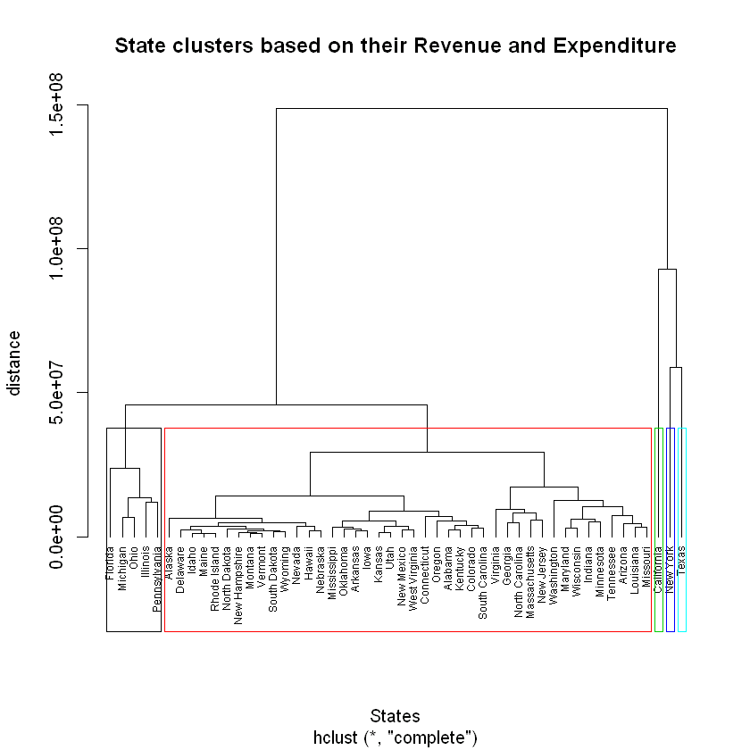

```r
# draw dendogram
plot(financesHClust,labels=Finances[,1],hang = -1,cex = 0.6,
     main='State clusters based on their Revenue and Expenditure',xlab="States",ylab="distance")
rect.hclust(financesHClust, k=5, border=1:5)#"red")
```

[figure not shown]

As we can see in the dendrogram, its clear that according to the Expenditure and Revenue values, 5 cluster is a logical cluster size. These clusters are;

- Cluster 1: Texas State
- Cluster 2: New York State
- Cluster 3: California State
- Cluster 4: Pennsylvania, Illinois, Ohio, Michigan and Florida
- Cluster 5: All states not listed above

# Hierarchical Cluster Analysis based on State's Revenue Only

```r
Finances2013Revenue=select(Finances,contains("Revenue")) # filtering columns which contain "Revenue"
Finances2013Revenue=cbind.data.frame(state=Finances[,1],Finances2013Revenue)
```

Stream of Revenues that are considered for the study are listed below. Note that, majority are revenues through tax.

```r
colnames(Finances2013Revenue)
```

1. "state"

2. "Total Revenue - General Revenue - Intergovernmental Revenue - From Federal,"

3. "Total Revenue - General Revenue - Intergovernmental Revenue - From Local,"

4. "Total Revenue - General Revenue - Total Taxes - General Sales and Gross Receipts Taxes,"

5. "Total Revenue - General Revenue - Total Taxes - Selective Sales and Gross Receipts Taxes,"

6. "Total Revenue - General Revenue - Total Taxes - License Taxes,"

7. "Total Revenue - General Revenue - Total Taxes - Individual Income Taxes,"

8. "Total Revenue - General Revenue - Total Taxes - Corporation Net Income Taxes,"

9. "Total Revenue - General Revenue - Total Taxes - All Other Taxes,"

10. "Total Revenue - General Revenue - Current Charges,"

11. "Total Revenue - General Revenue - Miscellaneous General Revenue,"

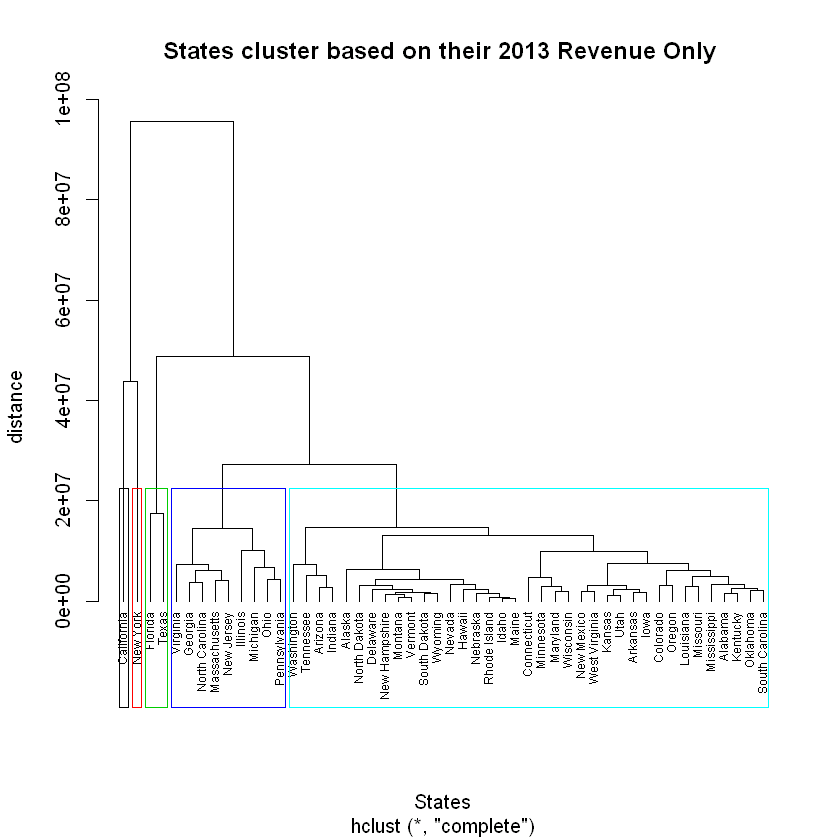

```r
RevenueHClust=hclust(dist(Finances2013Revenue[,-1],method="euclidean"))
Revenuegroup5 = cutree(RevenueHClust,5)
plot(RevenueHClust,labels=Finances2013Revenue[,1],hang = -1,cex = 0.6,
     main='States cluster based on their 2013 Revenue Only ',xlab="States",ylab="distance")
rect.hclust(RevenueHClust, k=5, border=1:5)
```

[figure not shown]

As we can see in the above dendrogram, its clear that, according to state's Revenue, cluster of size 5 is a significant size. The clusters under this clustering are:

- Cluster 1: California State
- Cluster 2: New York State
- Cluster 3: Texas State and Florida
- Cluster 4: Virginia, Georgia, North Carolina, Massachusetts, New Jersey,Illinois,Ohio, Michigan and Pennsylvania states
- Cluster 5: All states not clustered above

# Hierarchical Cluster Analysis based on their Expenditure Only

```r
Finances2013Exp=select(Finances,contains("Expenditure"))
Finances2013Exp=cbind.data.frame(state=Finances[,1],Finances2013Exp)
```

The functions of Expenditure are

```r
colnames(Finances2013Exp)
```

1. "state"

2. "General Expenditure, by Function: - Education,"

3. "General Expenditure, by Function: - Public Welfare,"

4. "General Expenditure, by Function: - Hospitals,"

5. "General Expenditure, by Function: - Health,"

6. "General Expenditure, by Function: - Highways,"

7. "General Expenditure, by Function: - Police Protection,"

8. "General Expenditure, by Function: - Correction,"

9. "General Expenditure, by Function: - Natural Resources,"

10. "General Expenditure, by Function: - Parks and Recreation,"

11. "General Expenditure, by Function: - Governmental Administration,"

12. "General Expenditure, by Function: - Interest on General Debt,"

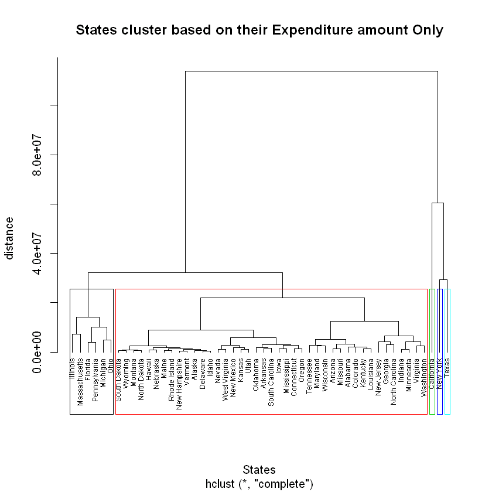

```r
ExpenditureHClust=hclust(dist(Finances2013Exp[,-1],method="euclidean"))
Expgroup5 = cutree(ExpenditureHClust,5)
plot(ExpenditureHClust,labels=Finances2013Exp[,1],hang = -1,cex = 0.6,
     main='States cluster based on their Expenditure amount Only',xlab="States",ylab="distance")
rect.hclust(ExpenditureHClust, k=5, border=1:5)
```

[figure not shown]

As we can see in the above dendrogram, its clear that the states clustered in to 5. These clusters are:

- Cluster 1: Texas State
- Cluster 2: New York State
- Cluster 3: California State
- Cluster 4: Illinois,Massachusetts, Florida,Pennsylvania,Michigan and Ohio States.
- Cluster 5: All states not clustered above

### Summary

```r
ByExpenditureAmount=c("California State","New York State","Texas State","Illinois, Massachusetts,
Florida, Pennsylvania, Michigan and Ohio States", "Others" )

ByRevenueAmount=c( "California State", "New York State", "Texas State and Florida"," Virginia, Georgia, North Carolina, Massachusetts, New Jersey,Illinois,Ohio, Michigan and Pennsylvania states", "Others")

ByRevenueExpenditureAmount=c("California State", "New York State","Texas State", "Pennsylvania, Illinois,Ohio, Michigan and Florida" , "Others")

summary=data.frame(ByExpenditureAmount,ByRevenueAmount,ByRevenueExpenditureAmount) rownames(summary)=c("Cluster_1", "Cluster_2", "Cluster_3", "Cluster_4", "Cluster_5")
summary
```

|  | ByExpenditureAmount | ByRevenueAmount | ByRevenueExpenditureAmount |
| --- | --- | --- | --- |
| Cluster_1 | California State | California State | California State |
| Cluster_2 | New York State | New York State | New York State |
| Cluster_3 | Texas State | Texas State and Florida | Texas State |
| Cluster_4 | Illinois, Massachusetts, Florida, Pennsylvania, Michigan and Ohio States | Virginia, Georgia, North Carolina, Massachusetts, New Jersey,Illinois,Ohio, Michigan and Pennsylvania states | Pennsylvania, Illinois, Ohio, Michigan and Florida |
| Cluster_5 | Others | Others | Others |